# GLM para dados binários com os dados fisheries

Maiara Menezes

18 outubro, 2025

## 1 Introdução

Dados binários são caracterizados por variáveis que podem assumir apenas dois estados possíveis (0-1). Exemplos incluem:

- Presença ausência de espécies
- Proporção de machos/fêmeas em uma população
- Sobreviveu ou não sobreviveu

```r
#~~~~~~~~~~~~~~~~~~~~~~~~~~~~~~~~
# 1. Importando o banco de dados
#~~~~~~~~~~~~~~~~~~~~~~~~~~~~~~~~
dados <- readRDS("../Dados/fisheries.rds")
```

Esses dados foram coletados a partir da pesca industrial de espinhel entre os anos 2003 e 2003. O objetivo da análise é associar a presença da espécie `Acanthocybium solandria` conhecida como cavala, uma espécie de relevância comercial, à algumas característica oceanográficas a fim contribuir para o sucesso de captura na pescaria, identificando a temperatura e profundidade ideais em que o espinhel podera ser colocado para aumentar a chances de captura desta espécie.

Vejemos brevemente algumas características gerais do banco de dados:

```r
#~~~~~~~~~~~~~~~~~~~~~~~~~~
# 2. Análise exploratória
#~~~~~~~~~~~~~~~~~~~~~~~~~~
str(dados)
```

```
## 'data.frame':    476 obs. of  33 variables:
##  $ Ano                     : int  2003 2003 2003 2003 2003 2003 2003 2003 2003 2003 ...
##  $ Mes                     : int  1 1 1 1 1 1 1 1 1 1 ...
##  $ N_anzol                 : int  1050 1050 1050 1050 1050 980 955 960 960 1052 ...
##  $ Barco                   : chr  "V201" "V201" "V201" "V201" ...
##  $ Pais                    : Factor w/ 3 levels "A","B","C": 2 2 2 2 2 2 2 2 2 2 ...
##  $ Long                    : num  -33.3 -38.8 -38.1 -35.8 -36.9 ...
##  $ Lat                     : num  -27.855 0.399 -15.695 -1.997 -19.667 ...
##  $ Thunnus_albacares       : num  4 27 5 55 7 11 29 58 6 14 ...
##  $ Thunnus_atlanticus      : num  0 32 0 0 4 18 0 0 4 13 ...
##  $ Katsuwonus_pelamis      : num  5 0 7 0 5 0 36 0 0 7 ...
##  $ Xiphias_gladius         : num  0 0 0 0 0 0 0 0 2 0 ...
##  $ Istiophorus_albicans    : num  3 0 0 11 0 5 0 12 3 0 ...
##  $ Tetrapturus_albidus     : num  3 6 0 0 2 7 0 0 2 0 ...
##  $ Makaira_nigricans       : num  0 0 0 0 0 0 0 0 0 0 ...
```

[output cut: 19 more lines]

## 2 Análise exploratória

A coluna `Acanthocybium_solandri` armazena informação sobre a quantidade de indivíduos da espécie cavala capturados.

Para fazer uma análise com dados binários utilizando este banco de dados, a nossa variável Y (número de cavalas capturadas) que é uma variável numérica discreta, deverá ser transformada em uma variável binária de presença e ausência, assumindo valores de 0 e 1. Para isto, temos que utilizar a função ´ifelse´ do pacote ´dplyr´ atribuindo valor = 1 nas observações onde houve a captura de pelo menos 1 indíviduo e valor = 0 para quando nenhum indivíduo foi capturado.

```r
#~~~~~~~~~~~~~~~~~~~~~~~~~~~~~~~~
# 3. Ajustando o formato da variável resposta
#~~~~~~~~~~~~~~~~~~~~~~~~~~~~~~~~

library(dplyr)

dados$Acanthocybium_solandri <- ifelse(dados$Acanthocybium_solandri >= 1 ,1, 0) %>%                       as.factor()
```

Podemos investigar visualmente se existe alguma relação da ocorrência da cavala com as nossas variáveis ambientais de interesse: temperatura e profundida.

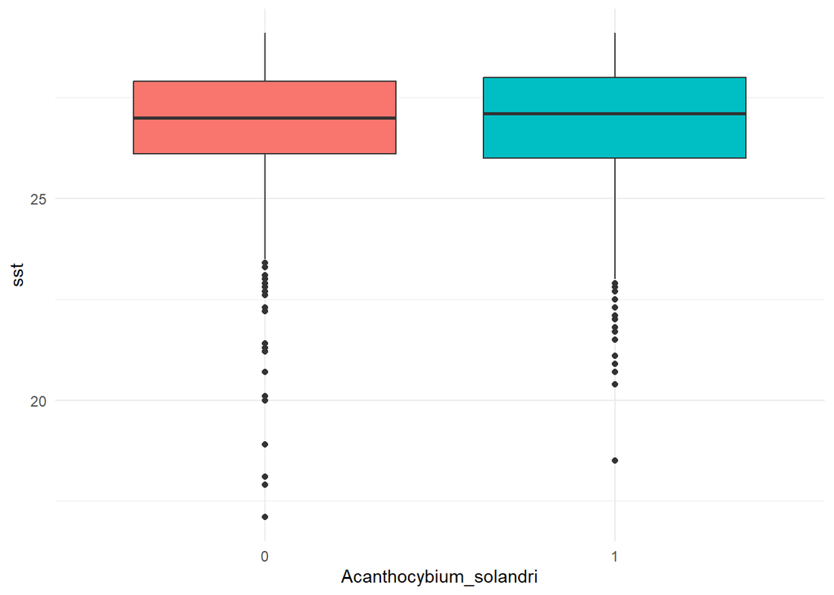

Observamos que a temperatura em torno de 26/27 graus possivelmente é aquele aonde as capturas da cavala são mais efetivas. Porém, há muitas ausências de captura também nas águas em torno desta temperatura. Então, vamos observar a relação com a profundidade.

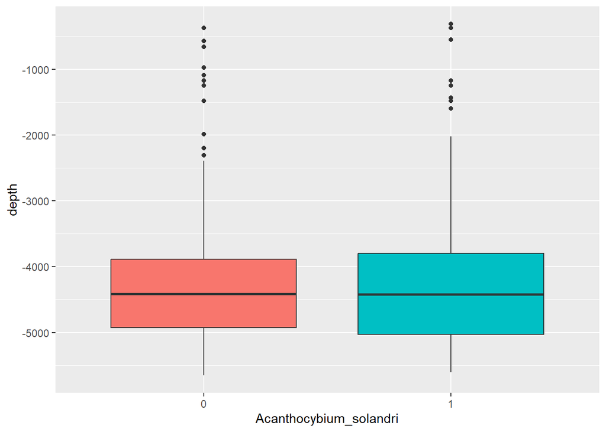

Podemos observar também a partir desse gráfico, que a média das capturas se concentrou em torno de 4500m de profundidade.

Ao analisar esses gráficos podemos sugerir que o sucesso de captura da cavala possivelmente está associado a regiões tropicais, com águas mais quentes (em torno de 26 graus C) e em profundidades em torno de 4500m. Mas as ausências de captura também foram bastante comum nessas condições, como observado nos gráficos acima. Será então que apenas a tempetura e a profundidade são informações suficientes para o pescadores definirem suas estratégias de pescaria para aumentar a chance de capturar essa espécie?

## 3 Hipóteses

Com base nessas breves observações, podemos começar a formular algumas hipóteses:

- $H_1:$ O sucesso de captura da cavala é maior em regiões tropicais com águas mais quentes
- $H_2:$ O sucesso de captura da cavala é maior em águas mais profundas (em torno de 4000 e 5000m)

## 4 Objetivos

Avaliar como condições oceanográficas (temperatura da superfcíe da água e profundidade) influenciam no sucesso de captura da cavala (Acanthocybium_solandri)

### 4.1 Objetivos específicos

1. **Estimar a influência da temperatura da água no sucesso de captura da cavala**
2. **Estimar a influência da profundidade no sucesso de captura da cavala**

## 5 Metodologia

Para avaliar se essas condições ocenográficas influenciam o sucesso de captura da cavala, será utilizado um modelo de regressão logística (i.e., modelo binomial), visto que a variável resposta (*Acanthocybium_solandri*) é binária (houve captura (1) vs. não houve captura (0)).

Podemos resumir o modelo conforme:

$$y_i \sim Binomial(n_i, p_i)$$

$$logit(p_i) = \eta_i
= \beta_0 +\sum_{j=1}^{J} \beta_j x_{ij}$$

onde $y_i$ é a i*esmo* pescaria, $n_i$ o número total de pescarias, $p_i$ a probabilidade da i*esmo* pescaria de capturar ao menos um indivíduo de cavala, $\beta_0$ o intercepto, $j$ número de covariáveis, $\beta_j$ os coeficientes que quantificam o efeito das covariáveis $x_j$.

Podemos escrever o modelo completo, conforme

$$logit(p_i) = \beta_0 + \sum_{j=1}^{J-1}
\beta_j Temperatura_{i,j} + \sum_{k=1}^{K-1} \gamma_k
Profundidade_{i,k}$$

> **Atenção:** Repare que o modelo contém 2 covariáveis numéricas - estamos, portanto, montando uma regressão logística com duas variáveis usando uma distribuição binomial!

Este único modelo é suficiente para responder aos dois objetivos específicos. No entanto, para vias de exercício, iremos testar diversos modelos para achar o modelo que melhor se ajuste aos dados. Para tanto, usaremos o método “forward-stepwise”, em que partimos do modelo nulo e inserimos uma covariável por vez.

Os modelos serão comparados pelos valores de AIC e, quando necessário, contrastados (testados) via o *teste de razão de verossimilhança*. Além disso, o ajuste dos modelos será analisado via análises gráficas dos resíduos.

## 6 Análises e Resultados

Iniciaremos as análises montando os modelos, partindo do modelo mais simples (modelo nulo) para o modelo mais complexo (contém todas as covariáveis).

```r
#~~~~~~~~~~~~~~~~~~~~~~~~~~~~~~~~
# 6. Testando modelos
#~~~~~~~~~~~~~~~~~~~~~~~~~~~~~~~~

## Modelo Nulo
mod0 <- glm(Acanthocybium_solandri ~ 1,
            family = binomial(link = "logit"),
            data = dados)

## Modelo 1
mod1 <- glm(Acanthocybium_solandri ~ sst,
            family = binomial(link = "logit"),
            data = dados)

## Modelo 2
mod2 <- glm(Acanthocybium_solandri ~ depth,
            family = binomial(link = "logit"),
            data = dados)

## Modelo 3
mod3 <- glm(Acanthocybium_solandri ~ sst + depth,
            family = binomial(link = "logit"),
            data = dados)
```

Agora que temos alguns modelos, podemos compará-los via valores de AIC

```r
#~~~~~~~~~~~~~~~~~~~~~~~~~~~~~~~~
# 7. Comparando os modelos
#~~~~~~~~~~~~~~~~~~~~~~~~~~~~~~~~

## Calcular os valores de AIC ##
aic <- AIC(mod0, mod1, mod2, mod3)


## Ordenar dos menores aos maiores valores ##
aic %>% arrange(-AIC)
```

```
##      df      AIC
## mod3  3 662.7492
## mod2  2 661.1989
## mod1  2 660.9526
## mod0  1 659.7232
```

De acordo com a tabela, constata-se que o modelo nulo (mod0) foi o que apresentou o melhor ajuste uma vez que apresentou o menor valor de AIC quando comparado aos demais modelos.

Antes de prosseguirmos com a validação visual do modelo escolhido, vamos comparar se esse modelo difere significativamente do segundo melhor modelo (mod1).

```r
#~~~~~~~~~~~~~~~~~~~~~~~~~~~~~~~~
# 8. Teste de razão de verossimilhança
#~~~~~~~~~~~~~~~~~~~~~~~~~~~~~~~~

#lmtest::lrtest(mod3, mod2) # mesma coisa
anova(mod0, mod1, test = "Chisq")
```

```
## Analysis of Deviance Table
##
## Model 1: Acanthocybium_solandri ~ 1
## Model 2: Acanthocybium_solandri ~ sst
##   Resid. Df Resid. Dev Df Deviance Pr(>Chi)
## 1       475     657.72
## 2       474     656.95  1  0.77063     0.38
```

Como o p-valor > 0.05, conclui-se que não existe diferença significativa entre o modelo nulo e o modelo que incorpora a temperatura como covariável. Logo, podemos assumir que **as covariáveis escolhidas não foram suficientes para explicar para estimar o sucesso de captura da cavala.**

Á título de exemplo, vamos analisar graficamente o ajuste do modelo:

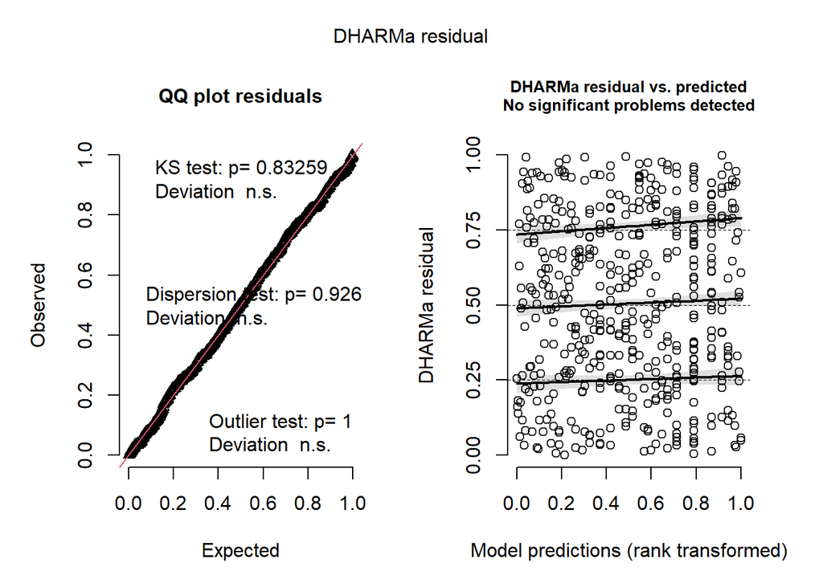

```r
#~~~~~~~~~~~~~~~~~~~~~~~~~~~~~~~~
# 9.Validação do modelo
#~~~~~~~~~~~~~~~~~~~~~~~~~~~~~~~~

library(DHARMa)

## Simulando os resíduos a partir do modelo escolhido ##
resid_sim <- simulateResiduals(mod1, n=1000)

plot(resid_sim)
```

Podemos fazer uma análise mais minuciosa dos resíduos do modelo 1 usando a função `check_model()` do pacote *performance*, só a título de exemplo:

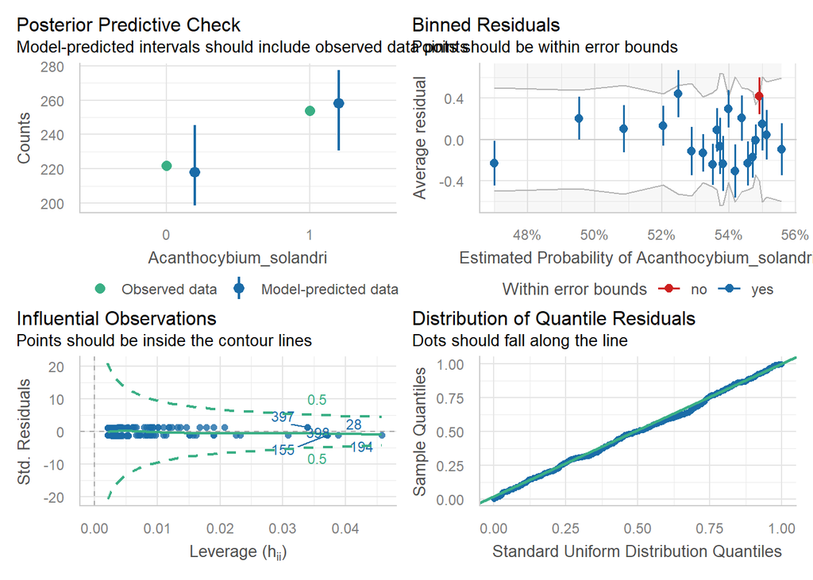

```r
library(performance)
check_model(mod1)
```

De maneira geral, têm-se um bom ajuste na normalidade dos resíduos, e os dados preditos pelo modelo estão alinhados com os dados observados. Entretanto, como já identificamos que o modelo nulo foi o melhor modelo, segundo o critério de AIC, não é viável considerar este modelo para determinar o sucesso de captura das cavalas.